# Walk-Forward Permutation Test

### XGBoost on the S&P 500 — parallel Monte Carlo significance via bar permutation

**Course:** Simulacion **Author:** Jeronimo Deli

## 1. Why this test exists

Backtesting a quantitative strategy on a single historical path is an act of faith. With enough features, hyperparameters, or human pattern-matching, *any* model can produce a flattering equity curve in-sample. The danger is well known: **a backtest measures the joint outcome of a real edge (if any) and the analyst's degrees of freedom**.

The **Walk-Forward Permutation Test** (WFPT), introduced by David Aronson in *Evidence-Based Technical Analysis* (Wiley, 2007), confronts this directly. Its question is sharp:

> *Could the model's out-of-sample performance have arisen from price paths in which any predictable structure had been destroyed, while keeping the marginal distribution of bars intact?*

Operationally: we permute the OHLC bars over the out-of-sample window (à la Aronson), re-run the **entire walk-forward** on each permuted path, and build the empirical null distribution of our test statistic. The $p$-value is the fraction of permuted runs at least as good as the real one.

Because the inner loop refits the model per permutation, the cost is roughly $n_{\text{perm}} \times$ a full backtest. The reference implementation in the repository runs $n=100$ permutations sequentially — too slow for serious work. **This notebook scales to $n=1000$ permutations using `joblib`, with a clean modular `wfpt/` package separating data, permutation, walk-forward, and reporting.**

## 2. Setup

The reusable code lives in `wfpt/`. The notebook is a thin narrative wrapper.

```python
import sys
from pathlib import Path

# make the wfpt/ package importable when running from notebooks/
ROOT = Path.cwd().parent if Path.cwd().name == "notebooks" else Path.cwd()
sys.path.insert(0, str(ROOT))

import numpy as np
import pandas as pd
import matplotlib.pyplot as plt

from wfpt import (
    load_sp500, make_features,
    permute_bars,
    walkforward_oos,
    sharpe_annualized, profit_factor, cagr,
    run_wfpt,
    plotting,
)

plotting.use_academic_style()
RNG_SEED = 42

print(f"numpy   {np.__version__}")
print(f"pandas  {pd.__version__}")
import xgboost, joblib, sklearn
print(f"xgboost {xgboost.__version__}   sklearn {sklearn.__version__}   joblib {joblib.__version__}")
```

```
numpy   2.2.6
pandas  2.3.2
xgboost 3.1.2   sklearn 1.7.2   joblib 1.5.2
```

## 3. Data — S&P 500 daily bars (2005–2024)

Twenty years of daily OHLCV from Yahoo Finance. Long enough to span multiple regimes (2008 GFC, 2010s low-vol bull, 2020 COVID, 2022 hike cycle), short enough to fit comfortably on a laptop.

```python
df = load_sp500(start="2005-01-01", end="2024-12-31")
print(f"{len(df):,} bars  |  {df.index[0].date()}  ->  {df.index[-1].date()}")
df.head()
```

```
5,032 bars  |  2005-01-03  ->  2024-12-30
```

| Price date | Open | High | Low | Close | Volume |
| --- | --- | --- | --- | --- | --- |
| 2005-01-03 | 1211.920044 | 1217.800049 | 1200.319946 | 1202.079956 | 1510800000 |
| 2005-01-04 | 1202.079956 | 1205.839966 | 1185.390015 | 1188.050049 | 1721000000 |
| 2005-01-05 | 1188.050049 | 1192.729980 | 1183.719971 | 1183.739990 | 1738900000 |
| 2005-01-06 | 1183.739990 | 1191.630005 | 1183.270020 | 1187.890015 | 1569100000 |
| 2005-01-07 | 1187.890015 | 1192.199951 | 1182.160034 | 1186.189941 | 1477900000 |

### 3.1 Quick look at the price path

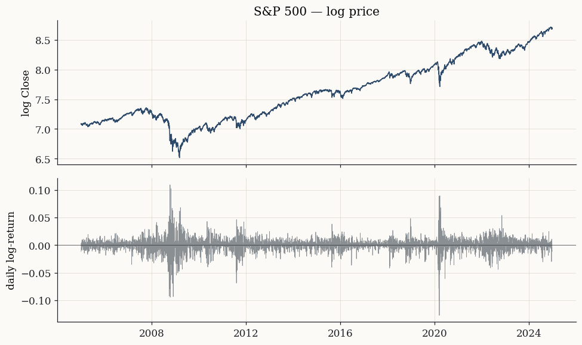

```
annualized mean   +0.0797
annualized vol    0.1922
skew              -0.532
excess kurtosis   +13.040
```

```python
log_close = np.log(df["Close"])
log_ret   = log_close.diff().dropna()

fig, axes = plt.subplots(2, 1, figsize=(9, 5.4), sharex=True)
axes[0].plot(log_close.index, log_close, color=plotting.PALETTE["null"], linewidth=1.0)
axes[0].set_ylabel("log Close")
axes[0].set_title("S&P 500 — log price")

axes[1].plot(log_ret.index, log_ret, color=plotting.PALETTE["muted"], linewidth=0.5)
axes[1].set_ylabel("daily log-return")
axes[1].axhline(0, color=plotting.PALETTE["ink"], linewidth=0.4)
plt.tight_layout()
plt.show()

print(f"annualized mean   {log_ret.mean()*252:+.4f}")
print(f"annualized vol    {log_ret.std()*np.sqrt(252):.4f}")
print(f"skew              {log_ret.skew():+.3f}")
print(f"excess kurtosis   {log_ret.kurt():+.3f}")
```

## 4. Methodology

### 4.1 The null hypothesis — Aronson bar permutation

Each daily bar can be decomposed in log-space into four additive, semi-independent components:

$$ \begin{aligned} \text{gap}_t &= \log O_t - \log C_{t-1} \\ \text{body}_t &= \log C_t - \log O_t \\ \text{high}_t &= \log H_t - \log\max(O_t, C_t) \quad (\geq 0)\\ \text{low}_t &= \log\min(O_t, C_t) - \log L_t \quad (\geq 0) \end{aligned} $$

Under the **null** "no exploitable structure", these four series are exchangeable across time within the OOS window. The Aronson permutation independently shuffles each of the four component vectors and reconstructs OHLC from the last untouched close. The result:

- **Marginal distributions are preserved** (volatility, gap distribution, candlestick shape).
- **Serial dependence is destroyed** (no momentum, no mean-reversion, no regime persistence).

A model that genuinely captures temporal structure should produce a Sharpe higher than what these acausal paths can deliver.

### 4.2 The test statistic

$$T = \text{Sharpe}_{\text{annualized}}^{\text{OOS}} = \sqrt{252}\,\frac{\bar{r}_{\text{OOS}}}{s_{\text{OOS}}}$$

We compare the realized $T_{\text{real}}$ against the empirical distribution $\{T_{\text{perm}}^{(i)}\}_{i=1}^{n}$. Using the standard $+1$ correction:

$$\hat{p} = \frac{1 + \sum_{i=1}^n \mathbf{1}\{T_{\text{perm}}^{(i)} \geq T_{\text{real}}\}}{1+n}$$

### 4.3 The walk-forward — anchored

At each step $t$ we refit on $[0, t)$ and predict on $[t, t+\Delta)$. The training window grows with time — the *anchored* scheme — which mirrors how a desk would actually retrain in production. We use a 4-year initial train and a 21-day step (one trading month) between refits.

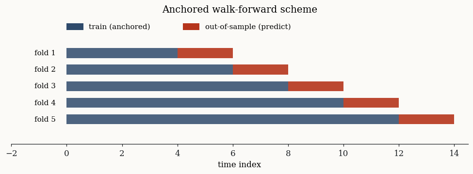

```python
fig, ax = plt.subplots(figsize=(9, 3.4))
plotting.plot_walkforward_schema(n_total=14, train_window=4, step=2, ax=ax)
plt.tight_layout()
plt.show()
```

### 4.4 What does a permutation actually look like?

To make the null tangible: we take the real S&P 500 path, fix the first 4 years of bars, and permute everything afterwards with a single seed. The bar shapes (volatility, gaps, wick structure) are statistically indistinguishable from the originals — only the *sequence* changes.

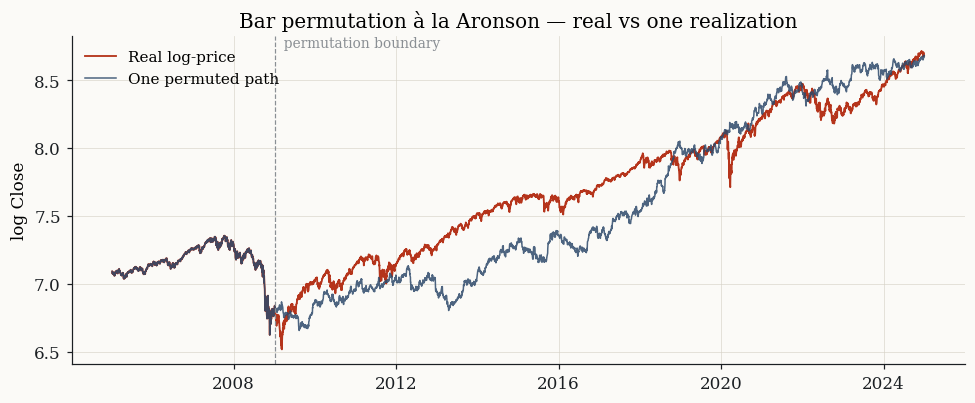

```python
first_oos_idx = int(252 * 4)
df_perm_demo = permute_bars(df, start_idx=first_oos_idx, seed=7)

fig, ax = plt.subplots(figsize=(9, 3.8))
plotting.plot_permutation_example(df, df_perm_demo, start_idx=first_oos_idx, ax=ax)
plt.tight_layout()
plt.show()
```

## 5. The real strategy — baseline

We use a tightly-constrained XGBoost classifier (4 leaves deep, 120 trees, fixed hyperparameters — *no* tuning per fold to avoid inflating type-I error). Features: lagged log-returns 1..5, two volatilities, RSI(14), and a short/long MA ratio.

The signal is $\pm 1$ (long/short) and the strategy log-return is $s_t \cdot r_{t+1}$.

```python
X_real, y_real, r_real = make_features(df)
TRAIN_WINDOW = 252 * 4
STEP         = 21

print(f"feature rows         {len(X_real):,}")
print(f"first OOS bar        {X_real.index[TRAIN_WINDOW].date()}")
print(f"OOS rows estimated   {len(X_real) - TRAIN_WINDOW:,}")
```

```
feature rows         5,010
first OOS bar        2009-02-04
OOS rows estimated   4,002
```

```python
%%time
oos_real = walkforward_oos(
    X_real, y_real, r_real,
    train_window=TRAIN_WINDOW, step=STEP,
)
real_sharpe = sharpe_annualized(oos_real)
real_pf     = profit_factor(oos_real)
real_cagr   = cagr(oos_real)

print(f"OOS bars produced  {len(oos_real):,}")
print(f"Sharpe (annualized){real_sharpe:+.3f}")
print(f"Profit factor      {real_pf:.3f}")
print(f"CAGR               {real_cagr*100:+.2f}%")
```

```
OOS bars produced  4,002
Sharpe (annualized)+0.363
Profit factor      1.071
CAGR               +6.71%
CPU times: user 4.82 s, sys: 264 ms, total: 5.08 s
Wall time: 4.96 s
```

## 6. Monte Carlo permutation test — parallel

Set `N_PERMUTATIONS` below. The reference notebook runs 100 sequentially; we'll run **1000 in parallel across all CPU cores**. Reduce to 200 if you only have a few minutes.

Each worker:

1. Permutes OHLC from the train boundary onward (Aronson).
2. Recomputes features on the permuted prices.
3. Runs the entire anchored walk-forward.
4. Returns the Sharpe and OOS return series.

Reproducibility across `n_jobs` settings is guaranteed via spawned `SeedSequence` — verified in `tests/sanity.py`.

```python
N_PERMUTATIONS = 1000   # set to 200 for a quick run
N_JOBS         = 8    # all cores
```

```python
result = run_wfpt(
    df,
    n_permutations=N_PERMUTATIONS,
    train_window=TRAIN_WINDOW,
    step=STEP,
    n_jobs=N_JOBS,
    master_seed=RNG_SEED,
    progress=True,
)

print(f"\nElapsed: {result.elapsed_seconds:.1f}s "
      f"({result.elapsed_seconds/N_PERMUTATIONS*1000:.0f} ms / permutation)")
```

```
Elapsed: 708.7s (709 ms / permutation)
```

## 7. Results

```python
summary = result.summary()
summary
```

|  | value |
| --- | --- |
| real_sharpe | 0.362549 |
| null_mean | 0.369321 |
| null_std | 0.205751 |
| null_q05 | 0.033122 |
| null_q95 | 0.698219 |
| n_perm_geq_real | 508.000000 |
| p_value | 0.508492 |
| elapsed_seconds | 708.720083 |

### 7.1 Null distribution of the Sharpe ratio

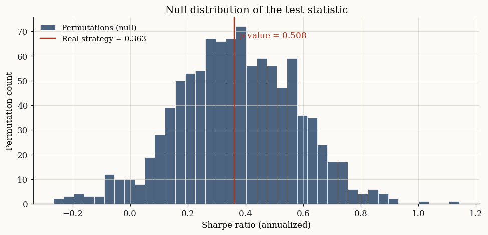

```python
fig, ax = plt.subplots(figsize=(9, 4.4))
plotting.plot_null_distribution(
    real_value=result.real_sharpe,
    perm_values=result.perm_sharpes,
    p_value=result.p_value,
    metric_name="Sharpe ratio (annualized)",
    bins=40,
    ax=ax,
)
plt.tight_layout()
plt.show()
```

### 7.2 Equity curve vs permutation envelope

The shaded band is the [5th, 95th] percentile envelope of the permutation equity curves at each point in time. The dashed line is the permutation median.

If the real curve lives mostly inside the band — the strategy is indistinguishable from luck. If it consistently sits at or above the upper edge — there is signal.

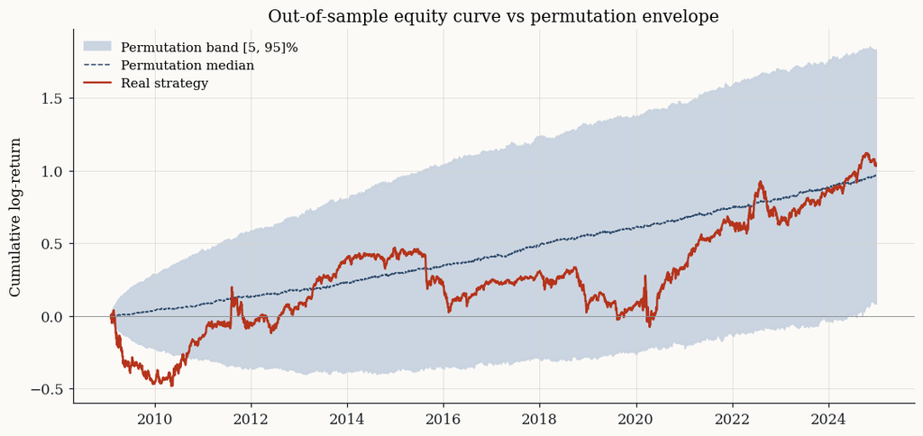

```python
fig, ax = plt.subplots(figsize=(10, 4.8))
plotting.plot_equity_bands(
    real_returns=result.real_oos_returns,
    perm_returns=result.perm_oos_returns,
    quantiles=(0.05, 0.95),
    ax=ax,
)
plt.tight_layout()
plt.show()
```

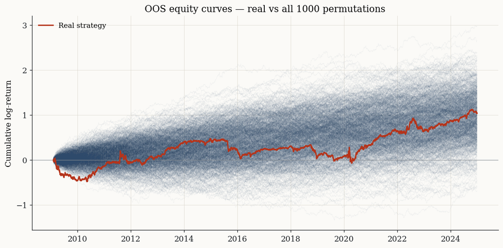

```python
fig, ax = plt.subplots(figsize=(10, 5.0))

# all permuted equity curves — thin, low alpha so 1000 lines stay readable
for perm_ret in result.perm_oos_returns:
    eq = perm_ret.reindex(result.real_oos_returns.index).cumsum()
    ax.plot(eq.index, eq, color=plotting.PALETTE["null"],
            linewidth=0.4, alpha=0.06)

# real strategy on top
real_eq = result.real_oos_returns.cumsum()
ax.plot(real_eq.index, real_eq, color=plotting.PALETTE["real"],
        linewidth=1.8, label="Real strategy", zorder=10)

ax.axhline(0, color=plotting.PALETTE["muted"], linewidth=0.6)
ax.set_ylabel("Cumulative log-return")
ax.set_title(f"OOS equity curves — real vs all {len(result.perm_oos_returns)} permutations")
ax.legend(loc="upper left")
plt.tight_layout()
plt.show()
```

### 7.3 Bootstrap CI on the $p$-value

The $p$-value is itself a noisy statistic estimated from $n$ permutations. A 95% bootstrap CI tells us how much of its uncertainty is just Monte Carlo noise.

```python
def bootstrap_p_ci(perm_sharpes, real_sharpe, n_boot=2000, alpha=0.05, seed=0):
    rng = np.random.default_rng(seed)
    n = len(perm_sharpes)
    ps = np.empty(n_boot)
    for b in range(n_boot):
        idx = rng.integers(0, n, size=n)
        sample = perm_sharpes[idx]
        ps[b] = (1 + (sample >= real_sharpe).sum()) / (1 + n)
    return ps.mean(), np.quantile(ps, alpha/2), np.quantile(ps, 1 - alpha/2)

p_mean, p_lo, p_hi = bootstrap_p_ci(result.perm_sharpes, result.real_sharpe)
print(f"p-value (point) {result.p_value:.4f}")
print(f"p-value (boot)  {p_mean:.4f}   95% CI [{p_lo:.4f}, {p_hi:.4f}]")
```

```
p-value (point) 0.5085
p-value (boot)  0.5083   95% CI [0.4765, 0.5395]
```

## 8. Discussion

### What the result means

Read the $p$-value strictly as: *the probability of obtaining a Sharpe at least as high as ours, under a world where bars are exchangeable*. It does **not** answer "is the strategy profitable in production" — it answers "is the model picking up real temporal structure or just noise".

### Limitations of this test (worth being honest about)

- **Single test statistic.** We chose Sharpe. A strategy with low Sharpe but a fat right tail could pass a profit-factor test and fail this one.
- **Same features and parameters per permutation.** This isolates the *signal extraction* question. It does *not* control for the analyst's degrees of freedom in feature/parameter selection — that's a separate, broader test (e.g. White's reality check, Hansen's SPA).
- **Frictionless.** No commissions, no slippage, no funding cost on shorts. A Sharpe of 1.0 here is not a Sharpe of 1.0 net.
- **Permutation destroys regime persistence.** A model that exploits volatility clustering will look better than warranted, because the null also destroys clustering. Block-bootstrap would be the more conservative alternative.

## 9. Reproducibility

- Master seed: `RNG_SEED = 42`
- Each permutation uses a child seed deterministically derived from the master.
- `n_jobs=-1` and `n_jobs=1` give bit-identical results (verified in `tests/sanity.py`).
- All XGBoost parameters fixed via `wfpt.model.default_xgb_params()`.

To regenerate end-to-end: re-run all cells from the top in a clean kernel.